# Doing Science: данные конъюнктурного опроса российских научных организаций и вузов

Виталий Рудь

Лаборатория экономики инноваций НИУ ВШЭ

Июль 13, 2018

# 1 О данных

## 1.1 Характеристики массива данных

Источник данных – обследование российских научных организций и вузов, проведенный летом 2017 года. В фокусе внимания – оценки восприятия состояния и перспектив российской науки, качества условий для ведения научно-исследовательской деятельности. Руководителям организаций предлагалось оценить деловой климат в науке по 50 отдельным направлениям. Для каждого направления собраны оценки по пятибальной шкале ликерта для текущей ситуации, а также ожидания на ближайшие 5 лет. Таким образом, итоговая картина делового климата формируется на основе 100 отдельных факторов.

```r
#загрузка данных
source_df <- import('merged.rds')
dictionary_climate <- import('dictionary_climate.xlsx') #словарь с краткими названиями факторов
```

Опрашивались научные организации академического профиля, вузы, а также организации, занятые прикладной наукой.

```r
#Описательные статистики вспомогательных переменных

df_variables <- source_df %>% dplyr:: select(-grep("q1", names(source_df)), -grep("q2", names(source_df)), -grep("q3", names(source_df)), -grep("q4", names(source_df)), -grep("qIV", names(source_df)))
skim(df_variables)
```

```
## Skim summary statistics
##  n obs: 361
##  n variables: 68
##
## Variable type: character
##  variable missing complete   n min max empty n_unique
##     title       0      361 361   9 230     0      361
##
## Variable type: numeric
##                 variable missing complete   n       mean            sd
##        captial_equipment       1      360 361      5.68        2.25
##       captial_facilities       1      360 361      5.36        2.96
##       domain_agriculture       0      361 361      0.21        0.41
##          domain_humanity       0      361 361      0.25        0.43
##          domain_medicine       0      361 361      0.2         0.4
##           domain_natural       0      361 361      0.58        0.49
##            domain_social       0      361 361      0.3         0.46
##         domain_technical       0      361 361      0.45        0.5
##                   emp_rd       1      360 361    303.02      531.96
##         finresource_base       1      360 361     -0.22        1.11
##     finresource_nonstate       1      360 361      3.53        2.68
##  finresource_statecompet       1      360 361      3.72        2.62
##                       FO       0      361 361      4.75        2.76
##                      inn       0      361 361  6e+09           2.2e+09
##                   number       0      361 361    822         488.67
##                      opf       0      361 361     37.86       46.99
##                  patents       1      360 361     -2.21        1.78
##        performance_class       0      361 361      1.69        0.67
##               priority_0       0      361 361      0.15        0.36
##               priority_1       0      361 361      0.47        0.5
##             priority_1_1       0      361 361      0.27        0.45
##             priority_1_2       0      361 361      0.36        0.48
##             priority_1_3       0      361 361      0.19        0.4
##             priority_1_9       0      361 361      0.5         0.5
##               priority_2       0      361 361      0.3         0.46
##             priority_2_1       0      361 361      0.19        0.39
##             priority_2_2       0      361 361      0.2         0.4
##             priority_2_3       0      361 361      0.089       0.28
##             priority_2_9       0      361 361      0.66        0.47
##               priority_3       0      361 361      0.29        0.46
```

[output cut: 90 more lines]

```
##   0           0            0         0          1       ▇▁▁▁▁▁▁▁
##   0           0            1         1          1       ▅▁▁▁▁▁▁▇
##   0       42030.75    117994.2  325658.7        2.2e+07 ▇▁▁▁▁▁▁▁
##   0           0            0         0.0026     0.91    ▇▁▁▁▁▁▁▁
##   0           0            0         0          1       ▇▁▁▁▁▁▁▁
##   0           0            0         0.018      1       ▇▁▁▁▁▁▁▁
##   0           0            0         0.00013    1       ▇▁▁▁▁▁▁▁
##   0           0.77         0.97      1          1       ▁▁▁▁▁▁▁▇
##   0           0            0         0.0053     1       ▇▁▁▁▁▁▁▁
##  -7.42       -2.57        -1.23      0          1.78    ▁▁▁▃▅▆▇▁
##   0           1            1         1          2       ▁▁▁▇▁▁▁▂
##  -1.1         5.36         5.97      6.33       7.87    ▁▁▁▁▁▃▇▂
##   0           0            0         0.0075     0.36    ▇▁▁▁▁▁▁▁
##   0           0.12         0.2       0.3        0.78    ▅▇▆▃▂▁▁▁
##   1           1            1         3          3       ▇▁▁▂▁▁▁▅
```

Видно, что база вспомогательных переменных не так чиста, как хотелось бы. В будущем, придется разобраться, что за за ошибки в ней. Но для данной версии работаем с немного грязной базой.

## 1.2 Сводные оценки: Деловой климат в науке – 2017

```r
#df <- df[df$priority_1==1,]
df <- source_df


climate_aggregateA <- df %>% dplyr:: select(grep("q1A", names(df)), grep("q2A", names(df)))
climate_aggregateB <- df %>% dplyr:: select(grep("q1B", names(df)), grep("q2B", names(df)))

meansA <- as.vector(colMeans(climate_aggregateA))
meansB <- as.vector(colMeans(climate_aggregateB))
q_col <- seq(1, 50, 1)
section_col <- c(rep(1,12),rep(2,6),rep(3,2),rep(4,5),rep(5,6),rep(6,7),rep(7,3),rep(8,9))
section_palette <- c("1"="#11C1FF", "2"="#00B050", "3"="#8D59B3", "4"="#9DD562", "5"="#EF8A46", "6"="#338DCD",
"7"="#FF5656", "8"="#FFC61A")
section_labels <-c("Кадровый потенциал",
"Материально-техническая база",
"Информационная инфраструктура",
"Научная кооперация",
"Финансирование",
"Научные результаты и их коммерциализация",
"Взаимодействие с обществом",
"Институциональные условия")



x_name <- "qA"
y_name <- "qB"
q_name <- "q"
section_name <- "section"


agg_df <- data.frame(q_col, section_col, meansA, meansB)
colnames(agg_df) <- c(q_name, section_name, x_name, y_name)
glimpse(agg_df)
```

```
## Observations: 50
## Variables: 4
## $ q       <dbl> 1, 2, 3, 4, 5, 6, 7, 8, 9, 10, 11, 12, 13, 14, 15, 16,...
## $ section <dbl> 1, 1, 1, 1, 1, 1, 1, 1, 1, 1, 1, 1, 2, 2, 2, 2, 2, 2, ...
## $ qA      <dbl> 3.603878, 3.479224, 3.692521, 2.936288, 4.174515, 4.17...
## $ qB      <dbl> 3.761773, 3.606648, 3.626039, 3.878116, 4.191136, 4.27...
```

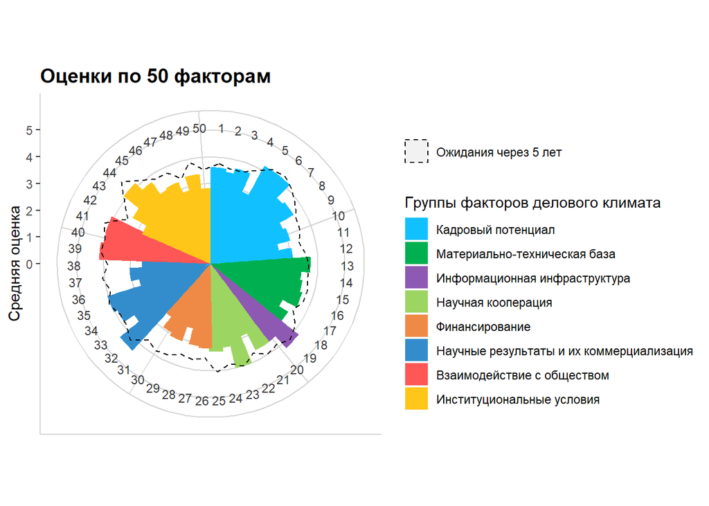

```r
image = ggplot(agg_df, aes(q, qA)) +
  geom_bar(stat="identity",width = 1.3, aes(fill=factor(section))) +
  scale_fill_manual("Группы факторов делового климата", values = section_palette, labels = section_labels) +
  geom_polygon(data=agg_df, aes(q, qB, alpha = "Ожидания через 5 лет"), lty=2, colour = 'black', fill=NA) +
  labs(alpha="") +
  ylim(0, 5.1) +
  coord_polar() +
  geom_text(data=agg_df, aes(x=q,y = 5.1, label = q), color = "black", alpha=0.8, size=3, family="sans") +
  ggtitle("Оценки по 50 факторам") +
  xlab('Номер фактора')+
  ylab('Средняя оценка')+
  theme(axis.title.x=element_blank(),
        plot.title=element_text(face="bold", size=14),
        panel.background = element_blank(),
        axis.line = element_line(colour = "light grey"),
        axis.text.x=element_blank(),
        panel.grid.major = element_line(colour="light grey"),
        panel.grid.minor = element_blank(),
        text=element_text(family="sans"))
image
```

```r
        #axis.ticks.x=element_blank(),
ggsave(file="first.svg", plot=image, width = 10, height = 8)
```